# Pedro Paramo

### Red de personajes de la novela "Pedro Páramo" de Juan Rulfo de 1955

por Rodrigo Fritz

El texto se encuentra en https://www.literatura.us/rulfo/paramo.html

Los personajes se pueden consultar en https://en.wikipedia.org/wiki/Pedro_P%C3%A1ramo aunque faltan algunos

Primero importar y minar el texto:

```python
import nltk, re, pprint
from nltk import word_tokenize
```

```python
# myfile = open("Pedro Paramo.txt", encoding='utf8')
# # print(myfile.read())
# # Or:
# # print(myfile.readlines())
# # Or:
# # for lines in myfile:
# #     print(lines.split()[:])
# for line in myfile:
#     line = line.strip()
#     print(line)
```

```python
myfile = open("Pedro Paramo.txt", encoding='utf8')
myfile.readlines()[:5]
```

```
['Juan Rulfo\n', '(1918-1986)\n', '\n', 'Pedro Páramo (1955)\n', '\n']
```

```python
myfile = open("Pedro Paramo.txt", encoding='utf8')
text = str(myfile.readlines()) #Necesitamos que text sea una sucesión de strings
```

```python
sents = nltk.sent_tokenize(text)
pprint.pprint(sents[:5]) #Primeras 5 líneas
```

```
["['Juan Rulfo\\n', '(1918-1986)\\n', '\\n', 'Pedro Páramo (1955)\\n', '\\n', "
 "'      Vine a Comala porque me dijeron que acá vivía mi padre, un tal Pedro "
 'Páramo.',
 'Mi madre me lo dijo.',
 'Y yo le prometí que vendría a verlo en cuanto ella muriera.',
 'Le apreté sus manos en señal de que lo haría, pues ella estaba por morirse y '
 'yo en un plan de prometerlo todo.',
 '«No dejes de ir a visitarlo —me recomendó.']
```

```python
from nltk.tokenize import word_tokenize # Passing the string text into word tokenize for breaking the sentences
token = word_tokenize(text, language='spanish')
print(len(token))
token[:10]
```

```
43645
```

```
['[', "'Juan", 'Rulfo\\n', "'", ',', "'", '(', '1918-1986', ')', '\\n']
```

```python
from nltk.probability import FreqDist
fdist = FreqDist(token)
fdist1 = fdist.most_common(20)
print('The',len(fdist1),'most common words:')
fdist1
```

```
The 20 most common words:
```

```
[(',', 3228),
 ("'", 2992),
 ('.', 2018),
 ('que', 1302),
 ('de', 1275),
 ('la', 903),
 ('a', 793),
 ('el', 656),
 ('y', 555),
 ('se', 547),
 ('\\n', 488),
 ('en', 482),
 ('?', 432),
 ('no', 397),
 ('lo', 355),
 ('los', 324),
 ('me', 297),
 ('por', 291),
 ('las', 266),
 ('Y', 263)]
```

```python
# importing stopwors from nltk library
from nltk import word_tokenize
from nltk.corpus import stopwords
a = set(stopwords.words('spanish'))
textl = word_tokenize(text, language='spanish')
stopws = [x for x in textl if x not in a]
print('Text length:',len(text))
print('Stopwords length:',len(stopws),'\n')
print(stopws[:17])
```

```
Text length: 199066
Stopwords length: 29160

['[', "'Juan", 'Rulfo\\n', "'", ',', "'", '(', '1918-1986', ')', '\\n', "'", ',', "'\\n", "'", ',', "'Pedro", 'Páramo']
```

```python
from nltk.probability import FreqDist
fdist = FreqDist(stopws)
fdist1 = fdist.most_common(1000)
print('The 20 most common words:')
fdist1[:20]
```

```
The 20 most common words:
```

```
[(',', 3228),
 ("'", 2992),
 ('.', 2018),
 ('\\n', 488),
 ('?', 432),
 ('Y', 263),
 ('“', 246),
 (';', 225),
 (':', 193),
 ('si', 178),
 ('”', 145),
 ("'\\n", 129),
 ('usted', 112),
 ('No', 111),
 ('Pedro', 110),
 ('!', 101),
 ('aquí', 92),
 ('El', 91),
 ('—No', 90),
 ('Páramo', 85)]
```

```python
nltk.pos_tag(token)[:20]
```

```
[('[', 'JJ'),
 ("'Juan", "''"),
 ('Rulfo\\n', 'NNP'),
 ("'", 'POS'),
 (',', ','),
 ("'", "''"),
 ('(', '('),
 ('1918-1986', 'JJ'),
 (')', ')'),
 ('\\n', 'NN'),
 ("'", "''"),
 (',', ','),
 ("'\\n", 'NNP'),
 ("'", 'POS'),
 (',', ','),
 ("'Pedro", 'FW'),
 ('Páramo', 'NNP'),
 ('(', '('),
 ('1955', 'CD'),
 (')', ')')]
```

Main Characters

```python
len([x for x in token if x == 'Pedro']), len([x for x in nltk.pos_tag(token) if x[0] == 'Páramo'])
```

```
(110, 85)
```

```python
len([x for x in token if x == 'Susana'])
```

```
51
```

```python
len([x for x in token if x == 'Fulgor'])
```

```
47
```

```python
len([x for x in token if x == 'Rentería'])
```

```
24
```

```python
len([x for x in token if x == 'Miguel'])
```

```
23
```

Minor Characters

```python
len([x for x in token if x == 'Damiana'])
```

```
19
```

```python
len([x for x in token if x == 'Justina'])
```

```
19
```

```python
len([x for x in token if x == 'Dorotea'])
```

```
17
```

```python
len([x for x in token if x == 'Eduviges'])
```

```
12
```

```python
len([x for x in token if x == 'Bartolomé'])
```

```
12
```

```python
len([x for x in token if x == 'Abundio'])
```

```
11
```

```python
len([x for x in token if x == 'Dolores'])
```

```
10
```

```python
len([x for x in token if x == 'Donis'])
```

```
5
```

```python
len([x for x in token if x == 'Toribio'])
```

```
5
```

```python
len([x for x in token if x == 'Fausta'])
```

```
5
```

```python
len([x for x in token if x == 'Gamaliel'])
```

```
5
```

```python
len([x for x in token if x == 'Florencio'])
```

```
2
```

```python
len([x for x in token if x == 'Valencia'])
```

```
2
```

```python
len([x for x in token if x == 'Inocencio'])
```

```
1
```

```python
len([x for x in token if x == 'Preciado']) #Juan Preciado, Dolores Preciado x 1
```

```
6
```

```python
len([x for x in token if x == 'Juan Preciado'])
```

```
0
```

```python
len([x for x in token if x == 'Juan']) #Juan Rulfo, Juan Preciado, Susana San Juan, Bartolomé San Juan
```

```
29
```

```python
P = 'Pedro' # Pedro Páramo
F = 'Fulgor' # Fulgor Sedano
S = 'Susana' # Susana San Juan
M = 'Miguel' # Miguel Páramo
D = 'Damiana' # Damiana Cisneros
R = 'Rentería' # Padre Rentería
J = 'Preciado' # Juan Preciado
Js= 'Justina' # Justina Díaz
Do= 'Dorotea' # sin apellido
E = 'Eduviges' # Eduviges Dyada
A = 'Abundio' # Abundio Martínez
Dl= 'Dolores' # Dolores Preciado
B = 'Bartolomé' # Bartolomé San Juan
Ds= 'Donis' # sin apellido
T = 'Toribio' # Toribio Aldrete
Fa= 'Fausta' # sin apellido
G = 'Gamaliel' # Gamaliel Villalpando
V = 'Valencia' # doctor Valencia
Fl= 'Florencio' # sin apellido
I = 'Inocencio' # Inocencio Osorio
```

```python
Lista = [P,F,S,M,D,R,J,Js,Do,E,A,Dl,B,Ds,T,Fa,G,V,Fl,I]
len(Lista)
```

```
20
```

```python
# G = nx.Graph()
# G.add_edge(J,D)
# G.add_edge(J,Do)
# G.add_edge(Fl,R)
# G.add_edge(Fl,S)
# G.add_edge(Fl,P)
```

```python
import networkx as nx
import matplotlib.pyplot as plt
```

Prueba:

```python
G = nx.Graph()
G.add_edge(I,P)
G.add_edge(Fl,R)
G.add_edge(Fl,S, weight=2)
G.add_edge(P,S, weight=13)
G.add_edge(P,F, weight=3)
G.add_edge(F,S, weight=2)
G.add_edge(P,J)
nx.write_weighted_edgelist(G, "test.weighted.edgelist")
```

```python
for i in G:
    print(len(G.edges(i)),G.edges(i))
```

```
1 [('Inocencio', 'Pedro')]
4 [('Pedro', 'Inocencio'), ('Pedro', 'Susana'), ('Pedro', 'Fulgor'), ('Pedro', 'Preciado')]
2 [('Florencio', 'Rentería'), ('Florencio', 'Susana')]
1 [('Rentería', 'Florencio')]
3 [('Susana', 'Florencio'), ('Susana', 'Pedro'), ('Susana', 'Fulgor')]
2 [('Fulgor', 'Pedro'), ('Fulgor', 'Susana')]
1 [('Preciado', 'Pedro')]
```

```python
G.size()
```

```
7
```

```python
G.size(weight='weight')
```

```
23.0
```

Minado de texto:

```python
txts = "\\n .\\n '\\n — —no “” :.,' ¡!¿?() ;"
stops = word_tokenize(txts)
```

```python
stops[:10]
```

```
['\\n', '.\\n', "'\\n", '—', '—no', '“', '”', ':', '.', ',']
```

```python
filt = []
for w in textl:
    if w not in stops:
        filt.append(w)
```

```python
from nltk.probability import FreqDist
fdist = FreqDist(filt)
fdist1 = fdist.most_common(1000)
print('The 20 most common words:')
fdist1[:20]
```

```
The 20 most common words:
```

```
[('que', 1302),
 ('de', 1275),
 ('la', 903),
 ('a', 793),
 ('el', 656),
 ('y', 555),
 ('se', 547),
 ('en', 482),
 ('no', 397),
 ('lo', 355),
 ('los', 324),
 ('me', 297),
 ('por', 291),
 ('las', 266),
 ('Y', 263),
 ('su', 240),
 ('le', 237),
 ('un', 233),
 ('con', 231),
 ('para', 206)]
```

```python
len(text)
```

```
199066
```

```python
len(textl)
```

```
43645
```

```python
m = len(filt)
m
```

```
33412
```

```python
c = 0
for i in range(m):
    if filt[i] == 'Susana':
        for w in range(30):
            k = w + 1
            if filt[i+k] == 'Pedro':
                c += 1
                print(c,filt[i:i+k+1],i,'\n')
```

```
1 ['Susana', 'Eso', 'es', 'lo', 'que', 'pasa', 'Cuando', 'venga', 'Pedro'] 23406

2 ['Susana', 'Se', 'recostó', 'sobre', 'su', 'pecho', 'abrazándola', 'hasta', 'que', 'ella', 'logró', 'levantar', 'aquella', 'cabeza', 'y', 'le', 'preguntó', '—¿Por', 'qué', 'lloras', 'Le', 'diré', 'a', 'Pedro'] 23799

3 ['Susana', 'San', 'Juan', 'Ésa', 'fue', 'una', 'de', 'las', 'cosas', 'que', 'Pedro'] 25302

4 ['Susana', 'San', 'Juan', 'se', 'revolvía', 'inquieta', 'de', 'pie', 'junto', 'a', 'la', 'puerta', 'Pedro'] 26833

5 ['Susana', 'San', 'Juan', 'estaba', 'nuevamente', 'dormida', 'y', 'afuera', 'chisporroteaba', 'el', 'sol', 'Se', 'encontró', 'con', 'Pedro'] 29212

6 ['Susana', '—¿Muerto', '¿Quién', '—La', 'señora.\\n', '—¿La', 'tuya', '—La', 'de', 'Pedro'] 31019

7 ['Susana', '’', 'Pedro'] 31563
```

```python
c = 0
for i in range(m):
    if filt[i] == 'Pedro':
        for w in range(30):
            k = w + 1
            if filt[i+k] == 'Susana':
                c += 1
                print(c,filt[i:i+k+1],i,'\n')
```

```
1 ['Pedro', 'Páramo', '—¿Y', 'yo', 'quién', 'soy', '—Tú', 'eres', 'mi', 'hija', 'Mía', 'Hija', 'de', 'Bartolomé', 'San', 'Juan.\\n', 'En', 'la', 'mente', 'de', 'Susana'] 22268

2 ['Pedro', 'Páramo', 'que', 'eres', 'buena', 'conmigo', 'No', 'le', 'contaré', 'nada', 'de', 'los', 'sustos', 'que', 'me', 'da', 'tu', 'gato', 'No', 'te', 'pongas', 'así', 'Justina', '—Tu', 'padre', 'ha', 'muerto', 'Susana'] 23822

3 ['Pedro', 'Páramo', 'fija', 'la', 'vista', 'en', 'Susana'] 26907

4 ['Pedro', 'Páramo', 'la', 'imagen', 'de', 'Susana'] 26960

5 ['Pedro', 'Páramo', 'abrió', 'la', 'puerta', 'y', 'se', 'estuvo', 'junto', 'a', 'ella', 'dejando', 'que', 'un', 'rayo', 'de', 'luz', 'cayera', 'sobre', 'Susana'] 29340

6 ['Pedro', 'Páramo', 'la', 'levantara', 'recostándola', 'contra', 'el', 'respaldo', 'de', 'la', 'cama', 'Susana'] 29465
```

```python
c = 0
for i in range(m):
    if filt[i] == 'Pedro':
        for w in range(30):
            k = w + 1
            if filt[i-k] == 'Susana':
                c += 1
                print(c,filt[i-k:i+1],k,i,'\n')

            elif filt[i+k] == 'Susana':
                c += 1
                print(c,filt[i:i+k+1],k,i,'\n')

            elif filt[i-k] == 'Susana.\\n':
                c += 1
                print(c,filt[i-k:i+1],k,i,'\n')
```

```
1 ['Pedro', 'Páramo', '—¿Y', 'yo', 'quién', 'soy', '—Tú', 'eres', 'mi', 'hija', 'Mía', 'Hija', 'de', 'Bartolomé', 'San', 'Juan.\\n', 'En', 'la', 'mente', 'de', 'Susana'] 20 22268

2 ['Susana', 'Eso', 'es', 'lo', 'que', 'pasa', 'Cuando', 'venga', 'Pedro'] 8 23414

3 ['Susana', 'Se', 'recostó', 'sobre', 'su', 'pecho', 'abrazándola', 'hasta', 'que', 'ella', 'logró', 'levantar', 'aquella', 'cabeza', 'y', 'le', 'preguntó', '—¿Por', 'qué', 'lloras', 'Le', 'diré', 'a', 'Pedro'] 23 23822

4 ['Pedro', 'Páramo', 'que', 'eres', 'buena', 'conmigo', 'No', 'le', 'contaré', 'nada', 'de', 'los', 'sustos', 'que', 'me', 'da', 'tu', 'gato', 'No', 'te', 'pongas', 'así', 'Justina', '—Tu', 'padre', 'ha', 'muerto', 'Susana'] 27 23822

5 ['Susana', 'San', 'Juan', 'Ésa', 'fue', 'una', 'de', 'las', 'cosas', 'que', 'Pedro'] 10 25312

6 ['Susana', 'San', 'Juan', 'se', 'revolvía', 'inquieta', 'de', 'pie', 'junto', 'a', 'la', 'puerta', 'Pedro'] 12 26845

7 ['Pedro', 'Páramo', 'fija', 'la', 'vista', 'en', 'Susana'] 6 26907

8 ['Pedro', 'Páramo', 'la', 'imagen', 'de', 'Susana'] 5 26960

9 ['Susana', 'San', 'Juan', 'estaba', 'nuevamente', 'dormida', 'y', 'afuera', 'chisporroteaba', 'el', 'sol', 'Se', 'encontró', 'con', 'Pedro'] 14 29226

10 ['Pedro', 'Páramo', 'abrió', 'la', 'puerta', 'y', 'se', 'estuvo', 'junto', 'a', 'ella', 'dejando', 'que', 'un', 'rayo', 'de', 'luz', 'cayera', 'sobre', 'Susana'] 19 29340

11 ['Pedro', 'Páramo', 'la', 'levantara', 'recostándola', 'contra', 'el', 'respaldo', 'de', 'la', 'cama', 'Susana'] 11 29465

12 ['Susana', '—¿Muerto', '¿Quién', '—La', 'señora.\\n', '—¿La', 'tuya', '—La', 'de', 'Pedro'] 9 31028

13 ['Susana', '’', 'Pedro'] 2 31565
```

```python
c = 0
for i in range(m):
    if filt[i] == 'Inocencio':
        for w in range(30):
            k = w + 1
            if filt[i-k] == 'Pedro':
                c += 1
                print(c,filt[i-k:i+1],k,i,'\n')
            elif filt[i+k] == 'Pedro':
                c += 1
                print(c,filt[i:i+k+1],k,i,'\n')
```

```
1 ['Inocencio', 'Osorio', 'Aunque', 'todos', 'lo', 'conocíamos', 'por', 'el', 'mal', 'nombre', 'del', 'Saltaperico', 'por', 'ser', 'muy', 'liviano', 'y', 'ágil', 'para', 'los', 'brincos', 'Mi', 'compadre', 'Pedro'] 23 3747
```

```python
a = 'Florencio'
b = 'Rentería'
c = 0
for i in range(m):
    if filt[i] == a:
        for w in range(100):
            k = w + 1
            if filt[i-k] == b:
                c += 1
                print(c,filt[i-k:i+1],k,i,'\n')
            elif filt[i+k] == b:
                c += 1
                print(c,filt[i:i+k+1],k,i,'\n')
```

```
1 ['Florencio', 'pero', 'eso', 'ya', 'lo', 'sé', 'No', 'te', 'aflijas', 'por', 'los', 'demás', 'no', 'te', 'apures', 'por', 'mí', 'Yo', 'tengo', 'guardado', 'mi', 'dolor', 'en', 'un', 'lugar', 'seguro', 'No', 'dejes', 'que', 'se', 'te', 'apague', 'el', 'corazón.', 'Enderezó', 'el', 'cuerpo', 'y', 'l…

2 ['Florencio', 'pero', 'eso', 'ya', 'lo', 'sé', 'No', 'te', 'aflijas', 'por', 'los', 'demás', 'no', 'te', 'apures', 'por', 'mí', 'Yo', 'tengo', 'guardado', 'mi', 'dolor', 'en', 'un', 'lugar', 'seguro', 'No', 'dejes', 'que', 'se', 'te', 'apague', 'el', 'corazón.', 'Enderezó', 'el', 'cuerpo', 'y', 'l…
```

```python
a = 'Florencio'
b = 'Susana'
c = 0
for i in range(m):
    if filt[i] == a:
        for w in range(100):
            k = w + 1
            if filt[i-k] == b:
                c += 1
                print(c,filt[i-k:i+1],k,i,'\n')
            elif filt[i+k] == b:
                c += 1
                print(c,filt[i:i+k+1],k,i,'\n')
```

```
1 ['Florencio', 'hablaba', '¿del', 'mío', '¡Oh', 'porqué', 'no', 'lloré', 'y', 'me', 'anegué', 'entonces', 'en', 'lágrimas', 'para', 'enjuagar', 'mi', 'angustia', '¡Señor', 'tú', 'no', 'existes', 'Te', 'pedí', 'tu', 'protección', 'para', 'él', 'Que', 'me', 'lo', 'cuidaras', 'Eso', 'te', 'pedí', 'Per…
```

```python
a = 'Florencio'
for j in range(len(Lista)):
    c = 0
    for l in range(m):
        if filt[l] == a:
            for w in range(100):
                k = w + 1
                if filt[l-k] == Lista[j]:
                    c += 1
                    print(c,filt[l-k:l+1],k,l,'\n')
                elif filt[l+k] == Lista[j]:
                    c += 1
                    print(c,filt[l:l+k+1],k,l,'\n')
    if c > 0:
        print(a,Lista[j],c,'\n')
```

```
1 ['Florencio', 'hablaba', '¿del', 'mío', '¡Oh', 'porqué', 'no', 'lloré', 'y', 'me', 'anegué', 'entonces', 'en', 'lágrimas', 'para', 'enjuagar', 'mi', 'angustia', '¡Señor', 'tú', 'no', 'existes', 'Te', 'pedí', 'tu', 'protección', 'para', 'él', 'Que', 'me', 'lo', 'cuidaras', 'Eso', 'te', 'pedí', 'Per…

Florencio Susana 1

1 ['Florencio', 'pero', 'eso', 'ya', 'lo', 'sé', 'No', 'te', 'aflijas', 'por', 'los', 'demás', 'no', 'te', 'apures', 'por', 'mí', 'Yo', 'tengo', 'guardado', 'mi', 'dolor', 'en', 'un', 'lugar', 'seguro', 'No', 'dejes', 'que', 'se', 'te', 'apague', 'el', 'corazón.', 'Enderezó', 'el', 'cuerpo', 'y', 'l…

2 ['Florencio', 'pero', 'eso', 'ya', 'lo', 'sé', 'No', 'te', 'aflijas', 'por', 'los', 'demás', 'no', 'te', 'apures', 'por', 'mí', 'Yo', 'tengo', 'guardado', 'mi', 'dolor', 'en', 'un', 'lugar', 'seguro', 'No', 'dejes', 'que', 'se', 'te', 'apague', 'el', 'corazón.', 'Enderezó', 'el', 'cuerpo', 'y', 'l…

Florencio Rentería 2
```

Aumentaremos el número de palabras entre personajes a 40, pues algunos faltan todavía con 30

```python
G = nx.Graph()
Tot_wgts = 0
for i in range(len(Lista)):
    for j in range(i+1,len(Lista)):
        c = 0
        for l in range(m):
            if filt[l] == Lista[i]:
                for w in range(40):
                    k = w + 1
                    if filt[l-k] == Lista[j]:
                        c += 1
                    elif filt[l+k] == Lista[j]:
                        c += 1
        if c > 0:
            print(Lista[i],Lista[j],c)
            G.add_edge(Lista[i],Lista[j],weight=c)
        Tot_wgts += c

#Falta agregar a mano a Florencio, pues sus edges están 45, 63 y 94 palabras de distancia
G.add_edge(Fl,S, weight=1)
G.add_edge(Fl,R, weight=2)

Tot_wgts
```

```
Pedro Fulgor 25
Pedro Susana 15
Pedro Miguel 10
Pedro Damiana 8
Pedro Rentería 8
Pedro Justina 4
Pedro Eduviges 1
Pedro Abundio 4
Pedro Dolores 5
Pedro Bartolomé 1
Pedro Toribio 1
Pedro Fausta 2
Pedro Gamaliel 1
Pedro Valencia 1
Pedro Inocencio 1
Fulgor Susana 2
Fulgor Miguel 8
Fulgor Damiana 2
Fulgor Rentería 1
Fulgor Dorotea 2
Fulgor Eduviges 3
Fulgor Dolores 4
Fulgor Bartolomé 1
Fulgor Toribio 5
Susana Rentería 2
Susana Justina 15
Susana Bartolomé 9
Susana Fausta 1
Susana Gamaliel 1
Miguel Damiana 3
Miguel Rentería 3
Miguel Dorotea 1
Miguel Eduviges 1
Damiana Dorotea 3
Damiana Eduviges 2
Damiana Abundio 2
Rentería Dorotea 1
Rentería Valencia 1
Preciado Dorotea 1
Preciado Donis 1
Justina Dorotea 1
Justina Bartolomé 3
Eduviges Toribio 1
Abundio Gamaliel 2
Dolores Donis 1
Fausta Valencia 1
```

```
171
```

```python
nx.number_of_edges(G)
```

[output not shown]

```python
# nx.write_weighted_edgelist(G, "Paramo_edgelist.txt")
```

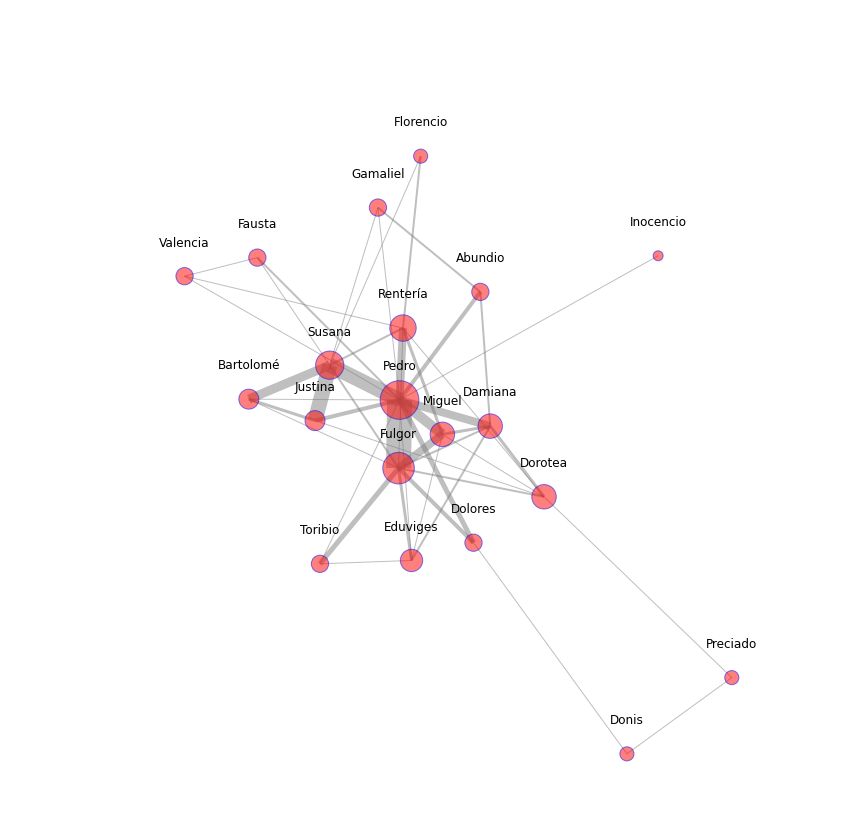

```python
ws = [d['weight'] for u,v,d in G.edges(data=True)]

node_sizes = []
for i in G:
    node_sizes.append(100*len(G.edges(i)))

plt.figure(figsize=(15,15))
plt.xlim(-1.2,1.2)
plt.ylim(-1.2,1.2)
pos = nx.spring_layout(G)
nx.draw(G, pos, node_color='r', edgecolors='b', node_size = node_sizes, width = ws, alpha=0.5, edge_color='grey')
for p in pos:  # raise text positions
    pos[p][1] += 0.1
nx.draw_networkx_labels(G, pos, font_size=12)
plt.show()
```

```python
Lista
```

```
['Pedro',
 'Fulgor',
 'Susana',
 'Miguel',
 'Damiana',
 'Rentería',
 'Preciado',
 'Justina',
 'Dorotea',
 'Eduviges',
 'Abundio',
 'Dolores',
 'Bartolomé',
 'Donis',
 'Toribio',
 'Fausta',
 'Gamaliel',
 'Valencia',
 'Florencio',
 'Inocencio']
```

Tamaño de la gráfica

```python
G.size() #edges
```

```
48
```

```python
G.number_of_edges()
```

```
48
```

```python
G.number_of_nodes()
```

```
20
```

```python
len(G) #nodes
```

```
20
```